# Show Up With A Mockup — Deck

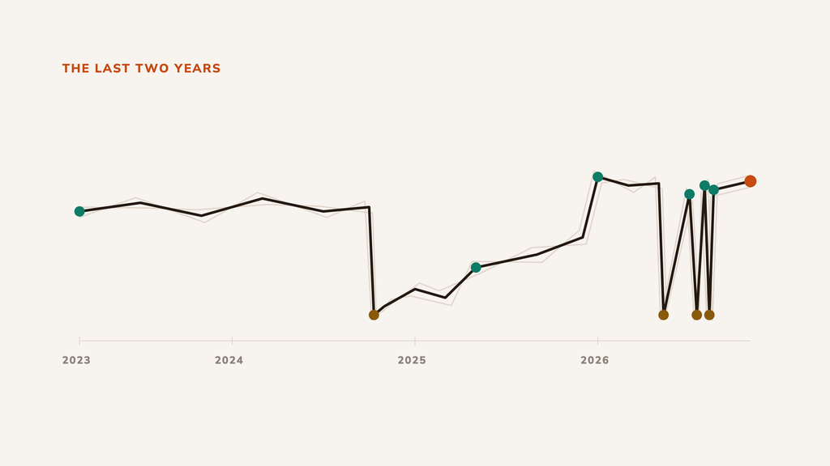

**Charlie Fuller** showupwithamockup.com

The last two years

Mar 2023 – Oct 2024

Risilience

Head of Learning

Laid off

**Charlie Fuller** showupwithamockup.com

The last two years

Risilience

Oct 2024

Laid off

Oct 2024 – Apr 2025

Consulting

AI Build Lab courses + independent AI consulting

Rebuilding

**Charlie Fuller** showupwithamockup.com

The last two years

Risilience

Oct 2024

Laid off

Consulting

2024–25

May 2025 – Dec 2025

AI Build Lab

Resident

Completed

**Charlie Fuller** showupwithamockup.com

The last two years

Risilience

Oct 2024

Laid off

Consulting

2024–25

AI Build Lab

May–Dec 2025

Jan 2026 – May 2026

[figure not shown]

Showed up with a mockup

Contentful

AI Solutions Partner

Laid off

**Charlie Fuller** showupwithamockup.com

The last two years

Risilience

Oct 2024

Laid off

Consulting

2024–25

AI Build Lab

May–Dec 2025

Contentful

Jan–May 2026

Laid off

Jul 2026

[figure not shown]

Showed up with a mockup

monday.com

Job offer

Offer rescinded

**Charlie Fuller** showupwithamockup.com

The last two years

Risilience

Oct 2024

Laid off

Consulting

2024–25

AI Build Lab

May–Dec 2025

Contentful

Jan–May 2026

Laid off

monday.com

Jul 2026

Offer rescinded

Aug 2026

[figure not shown]

Showed up with a mockup

Melior

Job offer

Offer rescinded

**Charlie Fuller** showupwithamockup.com

The last two years

Risilience

Oct 2024

Laid off

Consulting

2024–25

AI Build Lab

May–Dec 2025

Contentful

Jan–May 2026

Laid off

monday.com

Jul 2026

Offer rescinded

Melior

Aug 2026

Offer rescinded

Aug 2026

[figure not shown]

Showed up with a mockup

Xcel Energy

AI Operations, contract

Offer accepted

**Charlie Fuller** showupwithamockup.com

01

Show up with a mockup.

**Charlie Fuller** showupwithamockup.com

[figure not shown]

02

Who's in the room?

Upload a transcript. Find the people.

**Charlie Fuller** showupwithamockup.com

[figure not shown]

03

What I know.

Research, then audit. Gaps become named assumptions.

**Charlie Fuller** showupwithamockup.com

[figure not shown]

04

The brief.

The brief, then a hostile flaw check.

**Charlie Fuller** showupwithamockup.com

[figure not shown]

05

What to build.

The proposal, then a paste-ready spec.

**Charlie Fuller** showupwithamockup.com

[figure not shown]

06

The deck.

Bound by the flaw check, the verified law, the design guide.

**Charlie Fuller** showupwithamockup.com

[figure not shown]

07

The rehearsal agent.

The system prompt and the knowledge base.

**Charlie Fuller** showupwithamockup.com

[figure not shown]

08

Rehearse against the room.

Pushback grounded in something specific.

**Charlie Fuller** showupwithamockup.com

[figure not shown]

09

You're running evals on yourself.

Fix the source, not the symptom.

**Charlie Fuller** showupwithamockup.com

[figure not shown]